# A Bayesian VAR Suite for Forecasting the Australian Economy

What it forecasts, how it is judged, and what the evidence says — 1 to 12 quarters ahead

Published

July 16, 2026

**NoteIf you read nothing else**

This project forecasts **GDP growth, trimmed-mean inflation, the unemployment rate and the cash rate** for Australia, 1–12 quarters ahead, using 8 Bayesian VAR models plus 4 simple statistical benchmarks, all **combined into one pooled probability forecast**. Every model was tested by re-living the past: at each of 60 historical quarters it was re-estimated using only the data available at that date, made to forecast, and scored against what actually happened. The headline outputs are (i) the current fan-chart forecasts and event probabilities (§6), and (ii) the evidence on which models are reliable at which horizon (§5). Results are based on final-vintage published data; real-time vintages are not used, so revision-sensitive comparisons (especially GDP at short horizons) should be read with care — see the limitations section.

## 1. What this is, in plain terms

**The task.** Central-bank forecasting is not one prediction — it is a *distribution* over what might happen, at every horizon from next quarter to three years out. This pipeline produces those distributions (“density forecasts”) for the four policy variables, together with honest evidence about how good they are.

**Why a suite rather than one model.** No single model is best everywhere: tightly-disciplined models are robust three years out but sluggish next quarter; richly-parameterised models excel near-term and wander far-term; simple benchmarks are surprisingly hard to beat for inflation. So the production forecast is a **weighted pool** of all models’ distributions, and most of this report is about *which models earn their place and where*.

**TipWhere the equations live**

This report explains *what the suite does and what it finds*, in words. For the full mathematical specification — every prior, posterior, Gibbs step, forecasting recursion, scoring rule and combination formula, with equations and config keys — see the companion **technical reference** (`methodology.html`).

**Why “small open economy” is in the title.** Australia does not move world demand, world commodity prices, or the federal funds rate. Every VAR here partitions its variables into a **foreign block** (world activity, commodity prices, the US policy rate) and a **domestic block**, and imposes **block exogeneity**: foreign variables evolve as if Australia did not exist, while domestic variables respond to the world. Without this, a model happily “learns” from 30 years of data that Australian GDP drives world commodity prices — a spurious channel that quietly corrupts medium-term forecasts. One suite member (`small_unres`) deliberately *omits* the restriction so we can measure what it buys (§5.4).

**The data.** 13 quarterly series (3 foreign, 10 domestic), Australian data from the RBA and ABS, the foreign block from FRED. Data source for this run: **real**.

## 2. How to read the numbers (a two-minute guide)

Every model produces, for each variable and horizon, a full probability distribution. Three scores are used throughout, each answering a different question:

| Score | Question it answers | Better is |
| --- | --- | --- |
| **RMSE** | Was the *centre* of the forecast right? (root-mean-squared error of the point forecast) | lower |
| **CRPS** | Was the *whole distribution* right? Roughly: the average distance between the forecast distribution and the outcome. It rewards being close *and* being honest about uncertainty. | lower |
| **Log score** | How much probability did the model assign to what actually happened? It punishes overconfidence brutally: call an outcome “nearly impossible” and watch it occur, and your average never recovers. | higher |

CRPS and the log score usually agree. They diverge in episodes like 2020, when realizations landed far in the tails — the log score is dominated by those few quarters, CRPS much less so. That is why both are reported, and why score tables come in a with-COVID and an ex-COVID variant.

**Calibration and PITs.** A forecast distribution is *calibrated* if events it calls “20% likely” happen about 20% of the time. The tool for checking this is the **PIT** (probability integral transform): where in the forecast distribution did the outcome land, on a 0–1 scale? For a calibrated forecaster these values are uniform — the histogram is flat. A **hump** in the middle means intervals were too wide (overly cautious); a **U-shape** means too narrow (overconfident); a lopsided histogram means biased.

**Two views of accuracy.** Growth variables can be scored on each quarter’s outcome in isolation, or on where the accumulated *level* ends up. The headline here is the **level** view: “where is the price level / real GDP / the unemployment rate in two years?” — which is what policy cares about, and which exposes models whose small quarterly biases compound. A concrete example: a model that forecasts GDP growth of 0.7% every quarter when the truth averages 0.6% looks fine quarter by quarter (error 0.1pp) but is 1.2% too high on the GDP level after three years. The quarterly view is also reported (the scorecard’s §3) because it answers the complementary question — “did the model get the near-term dynamics right?”

**Horizons.** h = 1 is one quarter ahead; h = 12 is three years. Combination weights are estimated per horizon **bucket** — near (1–4), medium (5–8), far (9–12) — because the best model changes with horizon.

**Members vs combinations.** Rows named `combo_*` are pools (weighted mixtures of all members’ densities), not models. `combo_equal` weights all members equally; it is the famously hard-to-beat benchmark (“the forecast combination puzzle”). The performance-weighted schemes (`logscore`, `crps`, `pool`) adapt weights to the recent track record — trained on the same level loss the headline reports, with the COVID window excluded so a few extreme quarters cannot dictate the weights (README D20). `combo_bma` is a diagnostic, not a forecast: it shows which single model the data likes best.

## 3. The models

The variables. transform: how each series enters the models (dlog = quarterly log-change, i.e. growth; level = as is). delta: the prior’s default persistence (1 = behaves like a random walk, 0 = mean-reverting). ss_mean/ss_sd: the steady-state member’s prior on the long-run value (e.g. inflation anchored at 2.5% p.a. — the target midpoint).

| variable | label | block | transform | delta | ss_mean | ss_sd |
| --- | --- | --- | --- | --- | --- | --- |
| f_act | World activity (US real GDP) | foreign | dlog | 0 | 0.58 | 0.25 |
| f_comm | Commodity prices (RBA ICP, SDR) | foreign | dlog | 0 | 0.00 | 1.00 |
| f_rate | Foreign policy rate (US fed funds) | foreign | level | 1 | 2.50 | 1.00 |
| gdp_growth | Real GDP growth (qtr %) | domestic | dlog | 0 | 0.70 | 0.20 |
| cpi_inflation | Trimmed-mean CPI inflation (qtr %) | domestic | dlog | 0 | 0.62 | 0.15 |
| unemp_rate | Unemployment rate (%) | domestic | level | 1 | 4.50 | 0.75 |
| cash_rate | Cash rate (%) | domestic | level | 1 | 3.50 | 1.00 |
| rtwi | Real TWI (100*log) | domestic | loglevel | 1 | NA | 10.00 |
| tot | Terms of trade (100*log) | domestic | loglevel | 1 | NA | 10.00 |
| wpi_growth | Wage price index growth (qtr %) | domestic | dlog | 0 | 0.80 | 0.20 |
| emp_growth | Employment growth (qtr %) | domestic | dlog | 0 | 0.45 | 0.20 |
| cons_growth | Household consumption growth (qtr %) | domestic | dlog | 0 | 0.70 | 0.20 |
| bond10y | 10y AGS yield (%) | domestic | level | 1 | 4.00 | 1.00 |

Eight VARs and four univariate benchmarks. What distinguishes the VARs, in one line each (full profiles with their evaluation evidence: `model_scorecard.md` §6):

- **`small_minn`** — the workhorse: 8 variables, data-driven shrinkage, long-run priors on the persistent series.
- **`small_ss`** — the *steady-state* member: its long-run means are anchored to economics (inflation 2.5%, NAIRU 4.5%, neutral cash rate 3.5%) instead of sample averages; matters most at h ≥ 8, where every VAR forecast converges to its long-run mean.
- **`small_sv`** — *stochastic volatility*: the size of shocks changes over time, so uncertainty bands widen and narrow with the environment; fat-tailed errors absorb outliers.
- **`small_loose_p5` / `small_tight`** — deliberately under- and over-shrunk variants: the data speak more / less. They bracket the workhorse.
- **`medium_minn` / `medium_conj`** — 13-variable systems (adding wages, employment, consumption, terms of trade, the 10-year yield), with SV and constant volatility respectively.
- **`small_unres`** — the **control**: identical to the workhorse but *without* block exogeneity. Its only job is to measure whether the restriction helps (§5.4).

Benchmarks: a random walk (`rw`), a Bayesian AR(4) (`ar4`), the Stock–Watson-style trend-plus-noise model with stochastic volatility (`ucsv`, the canonical inflation benchmark), and the unconditional mean (`ucmean`). They are cheap, genuinely different, and every VAR must beat them to justify its complexity.

**The COVID quarters.** Three quarters of 2020 are 5–30σ events; untreated, they wreck coefficient and volatility estimates. Constant-volatility members down-weight those quarters’ *likelihood contribution* with scale factors estimated recursively (Lenza–Primiceri); SV members absorb them through fat-tailed errors instead. Nothing is deleted: the observations still enter the forecast jump-off. See README D17 for the full design and its empirical validation.

## 4. How the evaluation works

The evaluation re-lives history. At each forecast origin *t* (there are 60, ending one quarter before the sample ends), every member is re-estimated **using only data through t** — including the data-driven tightness selection and the COVID scale estimation, which are re-run inside each origin — and forecasts 1–12 quarters ahead. Forecasts are scored against what happened. Combination weights at *t* use only forecast scores whose outcome had been realized by *t*.

“No look-ahead” is a correctness property here, not a slogan: an automated test corrupts all post-origin data (×10⁶) and requires every forecast draw to be bit-identical; a reproducibility test requires identical results from identical seeds; and block exogeneity is verified numerically on every fit. All are enforced as hard gates — the pipeline refuses to produce output if one fails (§7).

## 5. Results

### 5.1 The headline: level accuracy by horizon

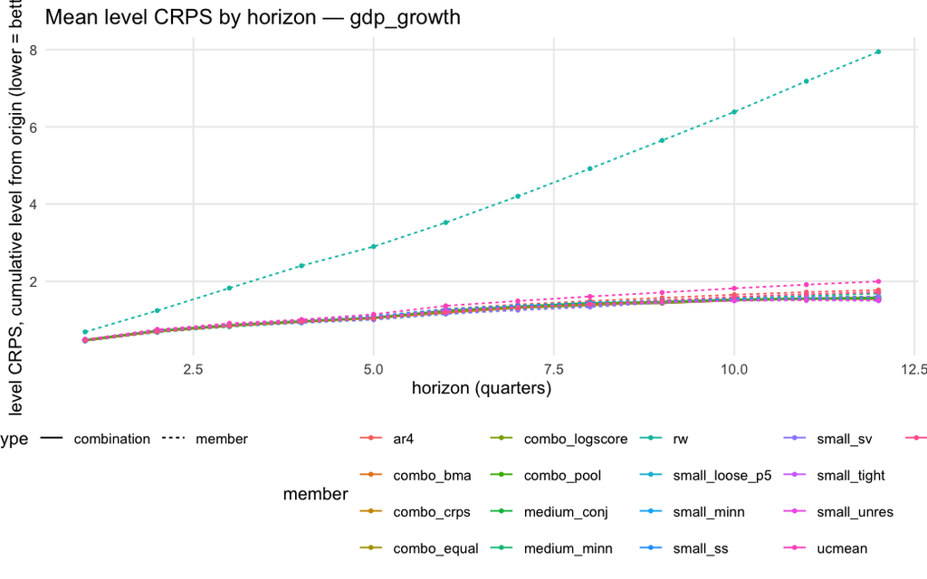

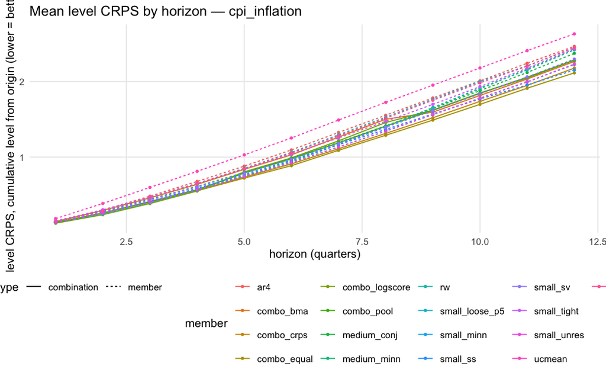

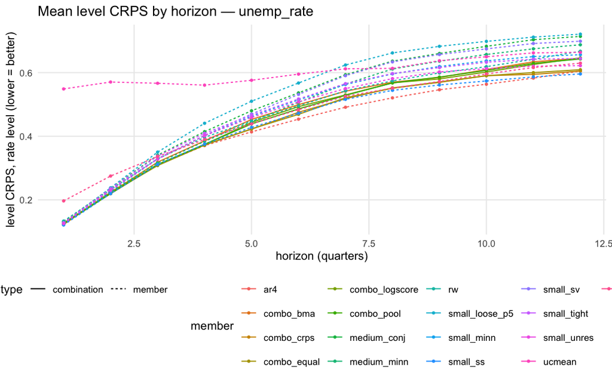

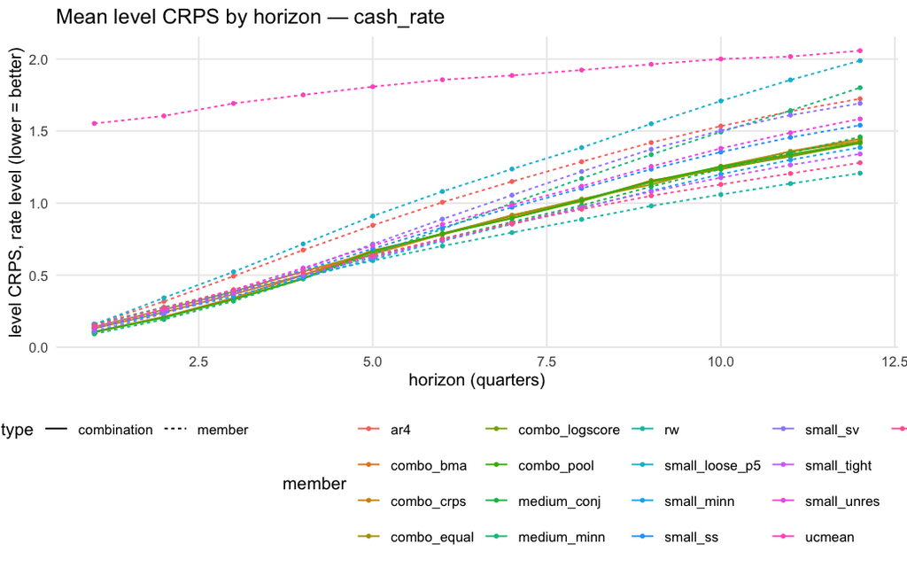

Mean level CRPS at h = 1, 4, 8, 12 (lower = better). For GDP and inflation this scores the cumulative level from the forecast origin; for unemployment and the cash rate, the rate itself.

| member | variable | crps.12 | crps.4 | crps.8 | crps.1 |
| --- | --- | --- | --- | --- | --- |
| medium_minn | cash_rate | 1.801 | 0.476 | 1.171 | 0.092 |
| combo_bma | cash_rate | 1.423 | 0.500 | 1.014 | 0.104 |
| combo_pool | cash_rate | 1.419 | 0.479 | 1.021 | 0.105 |
| combo_logscore | cash_rate | 1.416 | 0.474 | 1.014 | 0.107 |
| small_sv | cash_rate | 1.692 | 0.542 | 1.219 | 0.112 |
| combo_crps | cash_rate | 1.445 | 0.501 | 1.021 | 0.130 |
| small_minn | cash_rate | 1.386 | 0.481 | 0.967 | 0.130 |
| small_ss | cash_rate | 1.541 | 0.532 | 1.102 | 0.132 |
| small_unres | cash_rate | 1.585 | 0.549 | 1.118 | 0.134 |
| combo_equal | cash_rate | 1.430 | 0.525 | 1.028 | 0.141 |
| small_tight | cash_rate | 1.341 | 0.501 | 0.971 | 0.142 |
| ucsv | cash_rate | 1.280 | 0.520 | 0.957 | 0.152 |
| medium_conj | cash_rate | 1.459 | 0.499 | 0.984 | 0.157 |
| small_loose_p5 | cash_rate | 1.989 | 0.717 | 1.386 | 0.158 |
| ar4 | cash_rate | 1.724 | 0.674 | 1.287 | 0.160 |
| rw | cash_rate | 1.208 | 0.495 | 0.887 | 0.160 |
| ucmean | cash_rate | 2.058 | 1.751 | 1.924 | 1.553 |
| combo_logscore | cpi_inflation | 2.285 | 0.551 | 1.458 | 0.125 |
| rw | cpi_inflation | 2.420 | 0.561 | 1.403 | 0.131 |
| combo_crps | cpi_inflation | 2.177 | 0.558 | 1.313 | 0.132 |
| combo_equal | cpi_inflation | 2.114 | 0.554 | 1.289 | 0.133 |
| combo_pool | cpi_inflation | 2.281 | 0.568 | 1.411 | 0.136 |
| small_minn | cpi_inflation | 2.225 | 0.570 | 1.344 | 0.137 |
| small_unres | cpi_inflation | 2.231 | 0.568 | 1.346 | 0.137 |
| medium_minn | cpi_inflation | 2.421 | 0.574 | 1.399 | 0.137 |
| small_ss | cpi_inflation | 2.152 | 0.586 | 1.366 | 0.139 |
| small_sv | cpi_inflation | 2.296 | 0.605 | 1.395 | 0.140 |
| ucsv | cpi_inflation | 2.450 | 0.644 | 1.514 | 0.140 |
| ar4 | cpi_inflation | 2.465 | 0.678 | 1.554 | 0.142 |
| combo_bma | cpi_inflation | 2.265 | 0.639 | 1.501 | 0.147 |
| medium_conj | cpi_inflation | 2.372 | 0.613 | 1.412 | 0.150 |
| small_loose_p5 | cpi_inflation | 2.448 | 0.651 | 1.529 | 0.153 |
| small_tight | cpi_inflation | 2.432 | 0.651 | 1.473 | 0.155 |
| ucmean | cpi_inflation | 2.630 | 0.811 | 1.723 | 0.186 |
| medium_minn | gdp_growth | 1.685 | 0.922 | 1.374 | 0.453 |
| small_sv | gdp_growth | 1.602 | 0.930 | 1.334 | 0.461 |
| small_loose_p5 | gdp_growth | 1.608 | 0.977 | 1.443 | 0.465 |
| ucsv | gdp_growth | 1.718 | 0.951 | 1.410 | 0.466 |
| combo_bma | gdp_growth | 1.543 | 0.949 | 1.403 | 0.468 |
| combo_equal | gdp_growth | 1.586 | 0.946 | 1.390 | 0.468 |
| combo_crps | gdp_growth | 1.534 | 0.949 | 1.373 | 0.469 |
| small_ss | gdp_growth | 1.508 | 0.978 | 1.432 | 0.484 |
| combo_logscore | gdp_growth | 1.576 | 0.970 | 1.413 | 0.484 |
| ar4 | gdp_growth | 1.775 | 0.976 | 1.489 | 0.485 |
| combo_pool | gdp_growth | 1.567 | 0.972 | 1.443 | 0.486 |
| small_minn | gdp_growth | 1.524 | 0.997 | 1.450 | 0.488 |
| medium_conj | gdp_growth | 1.546 | 0.989 | 1.430 | 0.489 |
| small_unres | gdp_growth | 1.513 | 0.976 | 1.403 | 0.490 |
| ucmean | gdp_growth | 1.997 | 1.010 | 1.607 | 0.491 |
| small_tight | gdp_growth | 1.497 | 0.969 | 1.400 | 0.492 |
| rw | gdp_growth | 7.944 | 2.403 | 4.918 | 0.689 |
| small_ss | unemp_rate | 0.596 | 0.375 | 0.544 | 0.121 |
| medium_minn | unemp_rate | 0.688 | 0.384 | 0.611 | 0.122 |
| combo_bma | unemp_rate | 0.645 | 0.385 | 0.570 | 0.123 |
| small_minn | unemp_rate | 0.656 | 0.402 | 0.596 | 0.124 |
| combo_pool | unemp_rate | 0.643 | 0.375 | 0.568 | 0.125 |
| small_unres | unemp_rate | 0.622 | 0.402 | 0.581 | 0.125 |
| combo_crps | unemp_rate | 0.605 | 0.373 | 0.552 | 0.127 |
| combo_logscore | unemp_rate | 0.646 | 0.373 | 0.568 | 0.127 |
| combo_equal | unemp_rate | 0.609 | 0.372 | 0.551 | 0.127 |
| small_sv | unemp_rate | 0.699 | 0.402 | 0.634 | 0.127 |
| small_loose_p5 | unemp_rate | 0.721 | 0.441 | 0.662 | 0.128 |
| small_tight | unemp_rate | 0.644 | 0.409 | 0.597 | 0.128 |
| ar4 | unemp_rate | 0.605 | 0.371 | 0.521 | 0.130 |
| medium_conj | unemp_rate | 0.714 | 0.414 | 0.636 | 0.131 |
| rw | unemp_rate | 0.667 | 0.396 | 0.574 | 0.133 |
| ucsv | unemp_rate | 0.630 | 0.390 | 0.551 | 0.197 |
| ucmean | unemp_rate | 0.664 | 0.561 | 0.613 | 0.549 |

Mean level log predictive density (higher = better). −Inf marks a model that assigned essentially zero probability to an outcome that occurred; pooled combinations never do — one argument for pooling.

| member | variable | logdens.12 | logdens.4 | logdens.8 | logdens.1 |
| --- | --- | --- | --- | --- | --- |
| medium_minn | cash_rate | -2.73 | -1.23 | -2.24 | 0.45 |
| combo_bma | cash_rate | -2.52 | -1.24 | -2.09 | 0.36 |
| combo_pool | cash_rate | -2.45 | -1.20 | -2.05 | 0.34 |
| combo_logscore | cash_rate | -2.41 | -1.20 | -2.00 | 0.29 |
| combo_crps | cash_rate | -2.37 | -1.27 | -1.99 | 0.05 |
| combo_equal | cash_rate | -2.35 | -1.30 | -1.99 | -0.01 |
| small_ss | cash_rate | -2.56 | -1.33 | -2.13 | -0.05 |
| small_minn | cash_rate | -2.34 | -1.24 | -1.94 | -0.06 |
| small_unres | cash_rate | -2.53 | -1.35 | -2.14 | -0.06 |
| small_loose_p5 | cash_rate | -2.85 | -1.64 | -2.38 | -0.11 |
| medium_conj | cash_rate | -2.49 | -1.23 | -1.95 | -0.12 |
| small_tight | cash_rate | -2.50 | -1.31 | -2.10 | -0.14 |
| ucsv | cash_rate | -3.56 | -2.47 | -4.42 | -0.19 |
| ar4 | cash_rate | -2.92 | -1.56 | -2.41 | -0.23 |
| rw | cash_rate | -2.19 | -1.20 | -1.80 | -0.27 |
| small_sv | cash_rate | -2.75 | -1.51 | -2.53 | -0.75 |
| ucmean | cash_rate | -3.88 | -3.03 | -3.52 | -2.60 |
| combo_logscore | cpi_inflation | -3.06 | -1.21 | -2.31 | 0.15 |
| combo_pool | cpi_inflation | -3.06 | -1.21 | -2.31 | 0.13 |
| combo_crps | cpi_inflation | -2.88 | -1.17 | -2.16 | 0.11 |
| combo_equal | cpi_inflation | -2.85 | -1.17 | -2.14 | 0.11 |
| medium_conj | cpi_inflation | -18.77 | -5.55 | -18.08 | 0.05 |
| rw | cpi_inflation | -2.92 | -1.37 | -2.34 | 0.05 |
| combo_bma | cpi_inflation | -4.25 | -1.82 | -3.68 | 0.04 |
| ar4 | cpi_inflation | -8.37 | -2.57 | -4.83 | 0.03 |
| small_sv | cpi_inflation | -3.51 | -3.62 | -4.62 | 0.02 |
| small_minn | cpi_inflation | -17.37 | -6.20 | -18.48 | 0.00 |
| medium_minn | cpi_inflation | -3.79 | -3.56 | -3.66 | -0.02 |
| small_ss | cpi_inflation | -14.33 | -8.11 | -18.18 | -0.10 |
| ucsv | cpi_inflation | -9.94 | -6.23 | -10.88 | -0.12 |
| small_unres | cpi_inflation | -17.12 | -7.67 | -18.31 | -0.13 |
| small_loose_p5 | cpi_inflation | -9.99 | -8.30 | -17.74 | -0.14 |
| ucmean | cpi_inflation | -19.45 | -4.15 | -9.46 | -0.23 |
| small_tight | cpi_inflation | -26.37 | -14.47 | -28.29 | -0.33 |
| combo_equal | gdp_growth | -2.51 | -1.84 | -2.30 | -4.62 |
| combo_crps | gdp_growth | -2.50 | -1.84 | -2.30 | -4.63 |
| combo_logscore | gdp_growth | -2.51 | -1.90 | -2.37 | -4.69 |
| combo_pool | gdp_growth | -2.52 | -1.92 | -2.39 | -4.73 |
| combo_bma | gdp_growth | -2.57 | -2.05 | -2.91 | -4.81 |
| small_sv | gdp_growth | -2.48 | -4.41 | -2.70 | -10.02 |
| small_loose_p5 | gdp_growth | -2.55 | -5.46 | -3.48 | -11.44 |
| ar4 | gdp_growth | -3.44 | -5.75 | -4.48 | -Inf |
| medium_conj | gdp_growth | -2.59 | -4.56 | -3.22 | -Inf |
| medium_minn | gdp_growth | -2.57 | -4.40 | -2.91 | -Inf |
| rw | gdp_growth | -5.17 | -7.18 | -5.57 | -Inf |
| small_minn | gdp_growth | -2.84 | -5.56 | -4.01 | -Inf |
| small_ss | gdp_growth | -2.56 | -4.08 | -3.82 | -Inf |
| small_tight | gdp_growth | -2.56 | -5.95 | -3.77 | -Inf |
| small_unres | gdp_growth | -2.48 | -6.21 | -4.74 | -Inf |
| ucmean | gdp_growth | -4.49 | -8.04 | -5.33 | -Inf |
| ucsv | gdp_growth | -2.61 | -4.43 | -2.71 | -Inf |
| combo_crps | unemp_rate | -1.51 | -0.95 | -1.40 | 0.19 |
| combo_logscore | unemp_rate | -1.69 | -0.98 | -1.54 | 0.18 |
| combo_pool | unemp_rate | -1.68 | -1.00 | -1.54 | 0.18 |
| combo_equal | unemp_rate | -1.51 | -0.93 | -1.39 | 0.18 |
| combo_bma | unemp_rate | -1.77 | -1.12 | -1.52 | -0.59 |
| ucmean | unemp_rate | -1.63 | -1.35 | -1.49 | -1.35 |
| medium_minn | unemp_rate | -1.58 | -0.94 | -1.53 | -2.19 |
| small_unres | unemp_rate | -1.61 | -2.01 | -1.94 | -2.26 |
| ar4 | unemp_rate | -1.89 | -1.84 | -2.30 | -2.41 |
| small_tight | unemp_rate | -1.64 | -2.15 | -2.17 | -2.72 |
| rw | unemp_rate | -2.75 | -3.05 | -3.46 | -2.82 |
| small_ss | unemp_rate | -1.58 | -1.86 | -2.25 | -3.11 |
| medium_conj | unemp_rate | -1.73 | -1.32 | -1.84 | -3.24 |
| small_minn | unemp_rate | -1.74 | -1.76 | -2.15 | -3.27 |
| ucsv | unemp_rate | -1.56 | -1.52 | -1.40 | -3.41 |
| small_loose_p5 | unemp_rate | -1.66 | -1.60 | -1.84 | -3.79 |
| small_sv | unemp_rate | -1.65 | -1.31 | -1.58 | -4.52 |

### 5.2 The COVID caveat, quantified

Mean scores over a window containing 2020 are dominated by a few quarters. The same tables excluding realizations in 2020Q1–2021Q2 are in `output/tables/scores_by_horizon_excovid.csv`; where a ranking reverses between the two, the ex-COVID one is usually the better guide to normal times.

Near-horizon (h 1-4) mean level CRPS, all origins vs excluding COVID realizations: how much of each model’s score is one episode.

| member | crps_all | crps_excovid |
| --- | --- | --- |
| medium_minn | 0.399 | 0.312 |
| combo_logscore | 0.406 | 0.314 |
| combo_pool | 0.411 | 0.319 |
| combo_crps | 0.412 | 0.323 |
| small_minn | 0.423 | 0.326 |
| combo_bma | 0.419 | 0.327 |
| combo_equal | 0.416 | 0.327 |
| medium_conj | 0.438 | 0.332 |
| small_unres | 0.430 | 0.333 |
| small_ss | 0.425 | 0.333 |
| small_sv | 0.421 | 0.337 |
| small_tight | 0.439 | 0.344 |
| ucsv | 0.439 | 0.361 |
| ar4 | 0.460 | 0.362 |
| small_loose_p5 | 0.467 | 0.375 |
| rw | 0.619 | 0.472 |
| ucmean | 0.875 | 0.756 |

### 5.3 Do the combinations earn their keep?

Equal weights are the benchmark to beat, and the honest summary is that pooled forecasts buy **insurance and calibration** more than raw accuracy: a pool never takes a −∞ log score, never rides one model’s failure mode, and its intervals are better calibrated — but at any single variable × horizon a well-chosen member usually noses ahead. Weight-training details (level loss, COVID window excluded, shrinkage toward equal) are in README D20 — the 2026-07 audit showed that *without* those guards, log-score weights handed the far-horizon GDP bucket to the random walk on the strength of three 2020 quarters.

Final-origin weights of the optimal pool (averaged over targets):

Optimal-pool weights by horizon bucket (final origin, averaged over targets). Equal weight would be 1/12 ≈ 0.083 per member.

| member | far | medium | near |
| --- | --- | --- | --- |
| medium_minn | 0.025 | 0.194 | 0.423 |
| medium_conj | 0.025 | 0.078 | 0.128 |
| small_sv | 0.100 | 0.054 | 0.112 |
| rw | 0.291 | 0.235 | 0.103 |
| small_unres | 0.253 | 0.137 | 0.059 |
| small_ss | 0.025 | 0.025 | 0.025 |
| small_loose_p5 | 0.025 | 0.025 | 0.025 |
| small_minn | 0.025 | 0.025 | 0.025 |
| ar4 | 0.025 | 0.060 | 0.025 |
| small_tight | 0.025 | 0.025 | 0.025 |
| ucsv | 0.072 | 0.076 | 0.025 |
| ucmean | 0.109 | 0.066 | 0.025 |

BMA diagnostic (no shrinkage): which single model the data favour. By construction it concentrates; it is reported to be read, not used.

| member | weight |
| --- | --- |
| rw | 0.361 |
| medium_minn | 0.199 |
| ucsv | 0.158 |
| small_sv | 0.147 |
| medium_conj | 0.054 |
| small_ss | 0.031 |
| small_minn | 0.030 |
| small_unres | 0.013 |
| ar4 | 0.004 |
| small_tight | 0.002 |
| ucmean | 0.001 |
| small_loose_p5 | 0.001 |

*Weight evolution over time (near bucket): a member earning weight is a member that has been forecasting well lately.*

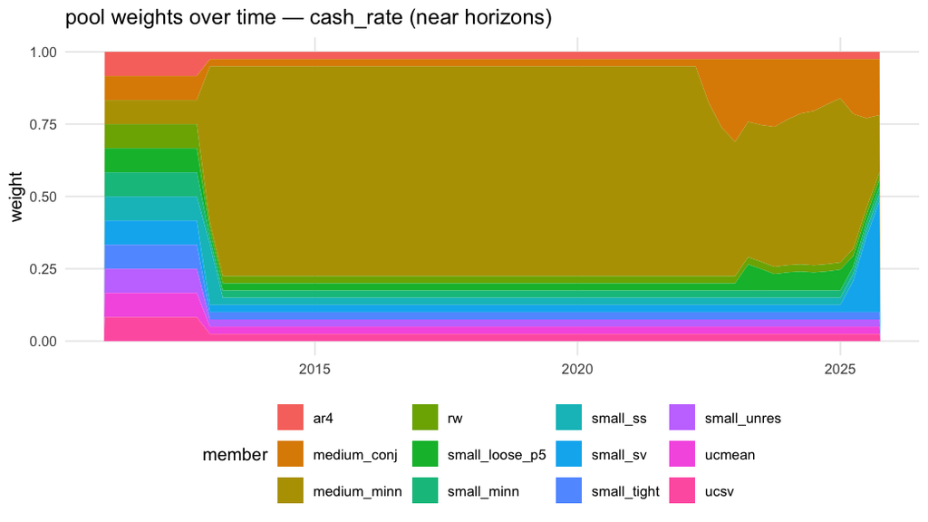

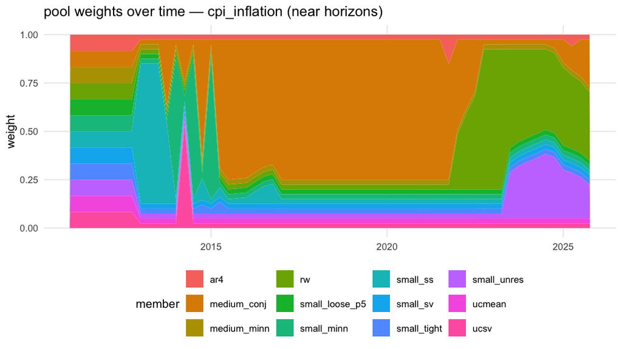

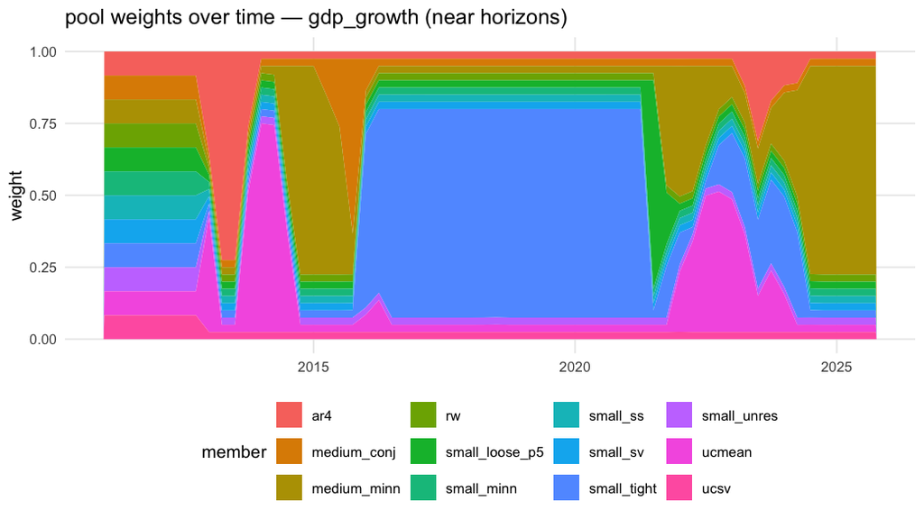

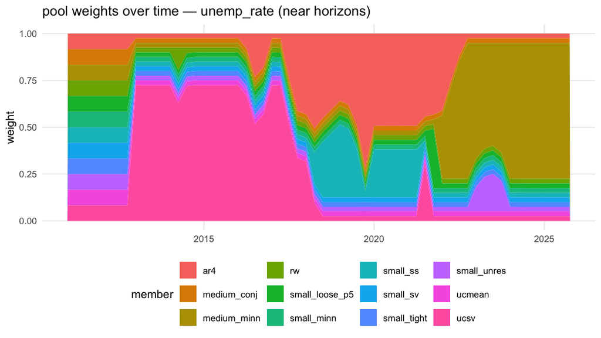

### 5.4 What does block exogeneity buy? (the control experiment)

`small_unres` is `small_minn` without the small-open-economy restriction. If the restriction helps, `small_minn` should win — especially at medium/far horizons where spurious domestic→foreign feedback compounds.

Mean level CRPS, h = 5-12: the block-exogenous workhorse vs its unrestricted twin. ‘yes’ = imposing the SOE structure improved the forecast.

| variable | small_minn | small_unres | restriction_helps |
| --- | --- | --- | --- |
| cash_rate | 1.018 | 1.171 | yes |
| cpi_inflation | 1.464 | 1.465 | yes |
| gdp_growth | 1.416 | 1.379 | no |
| unemp_rate | 0.587 | 0.569 | no |

### 5.5 Statistical significance

Diebold–Mariano tests ask whether a score difference is larger than its sampling noise (Harvey-corrected, autocorrelation-robust). Stars: `***` 1%, `**` 5%, `*` 10%. These losses are high-variance — dominated by a few episodes — so **absence of stars is weak evidence of nothing**; the tests have low power at long horizons.

Level-CRPS DM tests: pooled combinations vs the AR(4) and random-walk benchmarks. Negative statistic = the combination is more accurate.

| member | reference | variable | h | dm_crps | p_crps | sig_crps |
| --- | --- | --- | --- | --- | --- | --- |
| combo_equal | ar4 | cash_rate | 4 | -3.540 | 0.001 | *** |
| combo_logscore | ar4 | cash_rate | 4 | -3.317 | 0.002 | *** |
| combo_crps | ar4 | cash_rate | 4 | -3.769 | 0.000 | *** |
| combo_pool | ar4 | cash_rate | 4 | -3.126 | 0.003 | *** |
| combo_bma | ar4 | cash_rate | 4 | -2.294 | 0.026 | ** |
| combo_equal | rw | cash_rate | 4 | 0.459 | 0.648 |  |
| combo_logscore | rw | cash_rate | 4 | -0.365 | 0.716 |  |
| combo_crps | rw | cash_rate | 4 | 0.116 | 0.908 |  |
| combo_pool | rw | cash_rate | 4 | -0.274 | 0.785 |  |
| combo_bma | rw | cash_rate | 4 | 0.078 | 0.938 |  |
| combo_equal | ar4 | cash_rate | 8 | -1.625 | 0.110 |  |
| combo_logscore | ar4 | cash_rate | 8 | -1.214 | 0.230 |  |
| combo_crps | ar4 | cash_rate | 8 | -1.434 | 0.157 |  |
| combo_pool | ar4 | cash_rate | 8 | -1.184 | 0.242 |  |
| combo_bma | ar4 | cash_rate | 8 | -1.067 | 0.291 |  |
| combo_equal | rw | cash_rate | 8 | 1.128 | 0.264 |  |
| combo_logscore | rw | cash_rate | 8 | 2.371 | 0.021 | ** |
| combo_crps | rw | cash_rate | 8 | 1.431 | 0.158 |  |
| combo_pool | rw | cash_rate | 8 | 2.388 | 0.021 | ** |
| combo_bma | rw | cash_rate | 8 | 2.522 | 0.015 | ** |
| combo_equal | ar4 | cash_rate | 12 | -0.963 | 0.340 |  |
| combo_logscore | ar4 | cash_rate | 12 | -0.770 | 0.445 |  |
| combo_crps | ar4 | cash_rate | 12 | -0.819 | 0.417 |  |
| combo_pool | ar4 | cash_rate | 12 | -0.774 | 0.443 |  |
| combo_bma | ar4 | cash_rate | 12 | -0.688 | 0.495 |  |
| combo_equal | rw | cash_rate | 12 | 1.091 | 0.281 |  |
| combo_logscore | rw | cash_rate | 12 | 1.826 | 0.074 | * |
| combo_crps | rw | cash_rate | 12 | 1.484 | 0.144 |  |
| combo_pool | rw | cash_rate | 12 | 1.810 | 0.077 | * |
| combo_bma | rw | cash_rate | 12 | 1.965 | 0.055 | * |

[output cut: 90 more lines]

## 6. The current forecasts

Fan charts from the optimal-pool combination at the final origin. *How to read a fan chart: the line is history; the dashed line is the median forecast; the bands cover 30%/50%/70%/90% of the predictive distribution — the point is the width as much as the centre.*

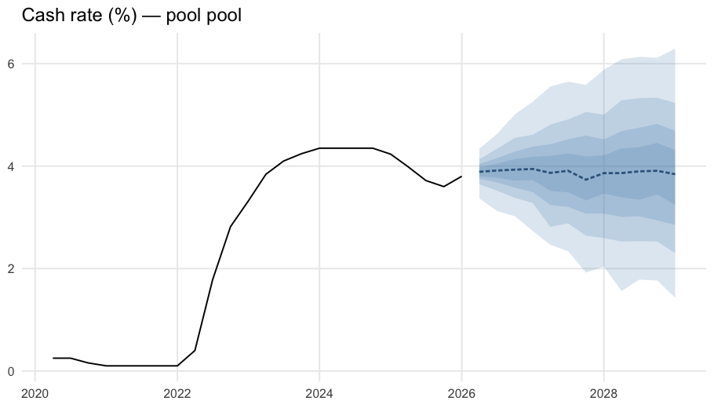

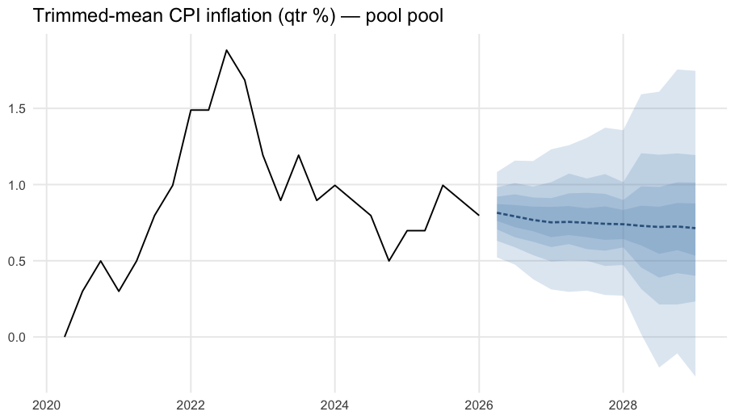

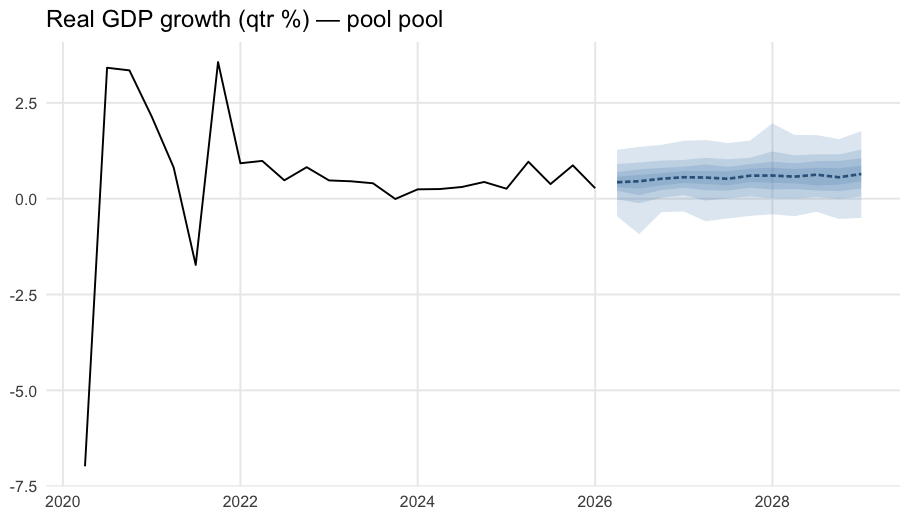

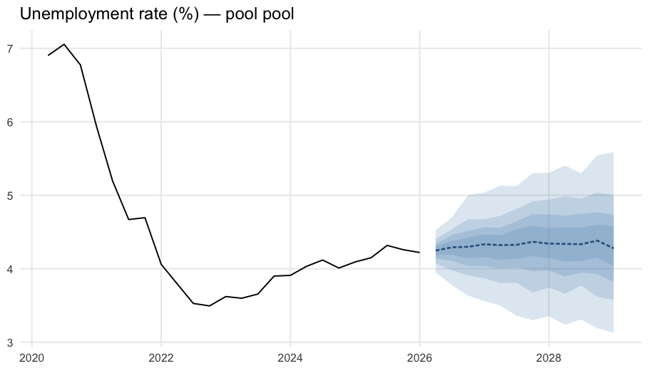

Combined (optimal pool) forecasts: median and 90% interval. Units: quarterly % growth for GDP and inflation; % for unemployment and the cash rate.

| variable | h | point | lo90 | hi90 |
| --- | --- | --- | --- | --- |
| gdp_growth | 1 | 0.43 | -0.46 | 1.28 |
| gdp_growth | 2 | 0.46 | -0.92 | 1.35 |
| gdp_growth | 4 | 0.56 | -0.33 | 1.51 |
| gdp_growth | 8 | 0.60 | -0.41 | 1.97 |
| gdp_growth | 12 | 0.64 | -0.50 | 1.76 |
| cpi_inflation | 1 | 0.81 | 0.52 | 1.08 |
| cpi_inflation | 2 | 0.79 | 0.47 | 1.16 |
| cpi_inflation | 4 | 0.75 | 0.31 | 1.23 |
| cpi_inflation | 8 | 0.74 | 0.27 | 1.36 |
| cpi_inflation | 12 | 0.71 | -0.26 | 1.75 |
| unemp_rate | 1 | 4.25 | 3.95 | 4.53 |
| unemp_rate | 2 | 4.29 | 3.78 | 4.70 |
| unemp_rate | 4 | 4.33 | 3.56 | 5.04 |
| unemp_rate | 8 | 4.34 | 3.35 | 5.30 |
| unemp_rate | 12 | 4.28 | 3.13 | 5.59 |
| cash_rate | 1 | 3.89 | 3.37 | 4.34 |
| cash_rate | 2 | 3.91 | 3.12 | 4.63 |
| cash_rate | 4 | 3.94 | 2.73 | 5.26 |
| cash_rate | 8 | 3.86 | 2.04 | 5.88 |
| cash_rate | 12 | 3.84 | 1.43 | 6.29 |

### 6.1 Event probabilities

Point forecasts hide the questions policy actually asks. From the pooled predictive distribution (probability-level pooling, which is exact for a linear pool):

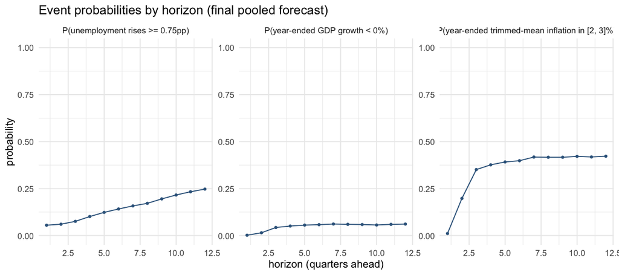

Event probabilities by horizon from the final pooled forecast (thresholds configurable in report.events).

| event | h=2 | h=4 | h=8 | h=12 |
| --- | --- | --- | --- | --- |
| P(year-ended GDP growth < 0%) | 0.01 | 0.05 | 0.06 | 0.06 |
| P(year-ended trimmed-mean inflation in [2, 3]%) | 0.20 | 0.38 | 0.42 | 0.42 |
| P(unemployment rises >= 0.75pp) | 0.06 | 0.10 | 0.17 | 0.25 |

### 6.2 Scenario: forecasts under imposed profiles

A forecast round rarely lets every variable float. The standard pattern: the **global block is taken as given over the whole projection window** (the international forecasts are an input, not an output), while domestic variables with good nowcasts — quarterly CPI, the unemployment rate — are pinned for **one quarter only**. The suite accepts exactly this ragged pattern: profiles per variable, each over its own horizon, supplied as a CSV (`report.conditional.profiles_file`) or inline in the config, and imposed by Waggoner–Zha conditional simulation — the joint shock distribution is updated exactly, so un-pinned variables (GDP, the cash rate) respond to the profiles through both the lag dynamics and the contemporaneous shock correlations, and the un-pinned quarters of a partially-pinned variable revert to model-driven forecasts consistent with the pinned quarter. See README D23 for the file format and mechanics; `data/example_forecast_profiles.csv` is the worked example.

This run imposes profiles for **cpi_inflation, f_act, f_rate, unemp_rate** (illustrative example values — replace the profiles file each round). In the table, `imposed = TRUE` marks quarters that were pinned rather than forecast; intervals there collapse to the imposed value by construction.

Scenario forecasts (VAR members, equal-weight pool) under the imposed profiles, alongside the unconditional forecasts in the table above.

| variable | h | target_date | point | lo90 | hi90 | imposed |
| --- | --- | --- | --- | --- | --- | --- |
| gdp_growth | 1 | 2026-04-01 | 0.53 | -0.19 | 1.25 | FALSE |
| gdp_growth | 2 | 2026-07-01 | 0.57 | -0.17 | 1.38 | FALSE |
| gdp_growth | 4 | 2027-01-01 | 0.61 | -0.21 | 1.41 | FALSE |
| gdp_growth | 8 | 2028-01-01 | 0.59 | -0.18 | 1.41 | FALSE |
| gdp_growth | 12 | 2029-01-01 | 0.63 | -0.28 | 1.49 | FALSE |
| cpi_inflation | 1 | 2026-04-01 | 0.80 | 0.80 | 0.80 | TRUE |
| cpi_inflation | 2 | 2026-07-01 | 0.80 | 0.52 | 1.08 | FALSE |
| cpi_inflation | 4 | 2027-01-01 | 0.79 | 0.48 | 1.10 | FALSE |
| cpi_inflation | 8 | 2028-01-01 | 0.77 | 0.43 | 1.13 | FALSE |
| cpi_inflation | 12 | 2029-01-01 | 0.75 | 0.38 | 1.13 | FALSE |
| unemp_rate | 1 | 2026-04-01 | 4.30 | 4.30 | 4.30 | TRUE |
| unemp_rate | 2 | 2026-07-01 | 4.31 | 4.04 | 4.59 | FALSE |
| unemp_rate | 4 | 2027-01-01 | 4.33 | 3.80 | 4.87 | FALSE |
| unemp_rate | 8 | 2028-01-01 | 4.39 | 3.55 | 5.21 | FALSE |
| unemp_rate | 12 | 2029-01-01 | 4.42 | 3.36 | 5.48 | FALSE |
| cash_rate | 1 | 2026-04-01 | 3.89 | 3.49 | 4.22 | FALSE |
| cash_rate | 2 | 2026-07-01 | 3.93 | 3.29 | 4.47 | FALSE |
| cash_rate | 4 | 2027-01-01 | 3.92 | 2.95 | 4.88 | FALSE |
| cash_rate | 8 | 2028-01-01 | 3.92 | 2.42 | 5.48 | FALSE |
| cash_rate | 12 | 2029-01-01 | 3.89 | 1.86 | 5.94 | FALSE |
| f_act | 1 | 2026-04-01 | 0.45 | 0.45 | 0.45 | TRUE |
| f_act | 2 | 2026-07-01 | 0.50 | 0.50 | 0.50 | TRUE |
| f_act | 4 | 2027-01-01 | 0.55 | 0.55 | 0.55 | TRUE |
| f_act | 8 | 2028-01-01 | 0.55 | 0.55 | 0.55 | TRUE |
| f_rate | 1 | 2026-04-01 | 3.50 | 3.50 | 3.50 | TRUE |
| f_rate | 2 | 2026-07-01 | 3.40 | 3.40 | 3.40 | TRUE |
| f_rate | 4 | 2027-01-01 | 3.20 | 3.20 | 3.20 | TRUE |
| f_rate | 8 | 2028-01-01 | 3.00 | 3.00 | 3.00 | TRUE |

## 7. Is any of this trustworthy? (calibration and diagnostics)

### 7.1 Calibration

PIT histograms (see §2 for how to read them), h = 1 and h = 4:

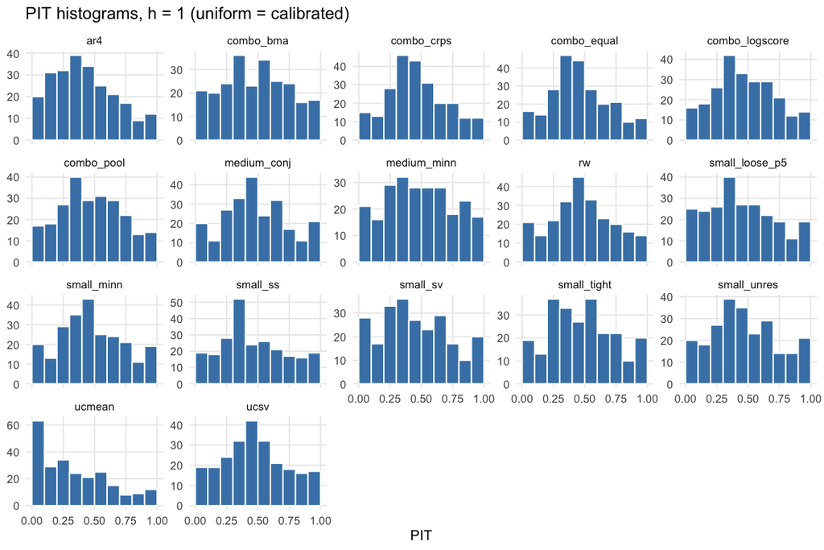

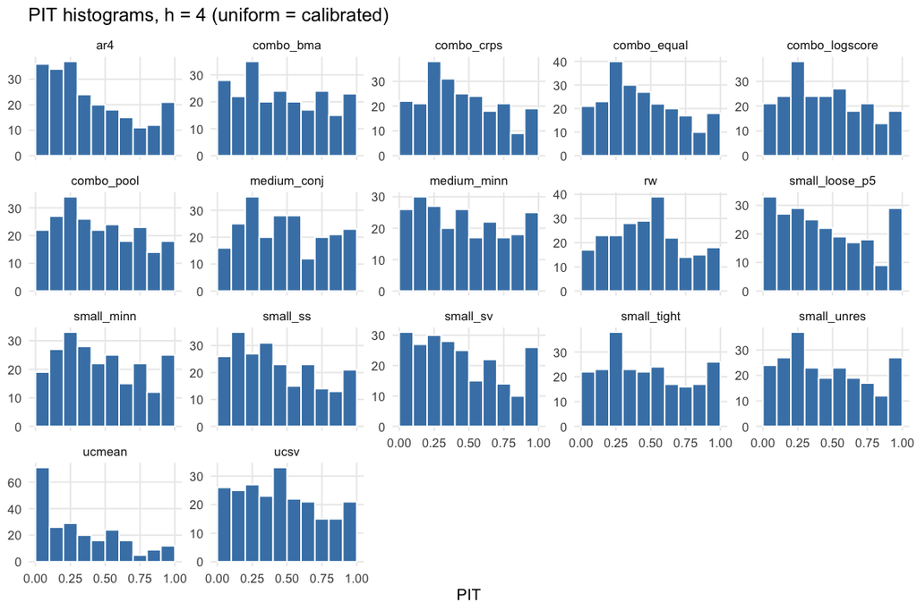

At horizons beyond 1 the usual uniformity test is invalid (overlapping forecasts make PITs serially correlated), so the table below tests the first two moments with autocorrelation-robust standard errors: **location** (is the mean PIT 0.5? — bias) and **dispersion** (is the PIT variance 1/12? — too wide/too narrow), per horizon. Small p-values flag a problem.

PIT moment-test failures at the 5% level (full table: output/tables/pit_tests.csv). mean_pit > 0.5 = forecasts too low on average; var_pit > 1/12 ≈ 0.083 = intervals too narrow.

| member | variable | h | n | mean_pit | p_location | var_pit | p_dispersion |
| --- | --- | --- | --- | --- | --- | --- | --- |
| ar4 | cash_rate | 1 | 60 | 0.386 | 0.000 | 0.048 | 0.000 |
| ar4 | cash_rate | 2 | 59 | 0.344 | 0.000 | 0.071 | 0.272 |
| ar4 | cash_rate | 3 | 58 | 0.319 | 0.001 | 0.093 | 0.526 |
| ar4 | cash_rate | 4 | 57 | 0.300 | 0.005 | 0.111 | 0.138 |
| ar4 | cash_rate | 5 | 56 | 0.289 | 0.012 | 0.124 | 0.051 |
| ar4 | cash_rate | 6 | 55 | 0.283 | 0.024 | 0.134 | 0.024 |
| ar4 | cash_rate | 7 | 54 | 0.283 | 0.044 | 0.142 | 0.011 |
| ar4 | cash_rate | 8 | 53 | 0.285 | 0.070 | 0.150 | 0.004 |
| ar4 | cash_rate | 9 | 52 | 0.286 | 0.104 | 0.162 | 0.000 |
| ar4 | cash_rate | 10 | 51 | 0.286 | 0.134 | 0.171 | 0.000 |
| ar4 | cash_rate | 11 | 50 | 0.294 | 0.182 | 0.178 | 0.000 |
| ar4 | cash_rate | 12 | 49 | 0.298 | 0.218 | 0.184 | 0.000 |
| ar4 | cpi_inflation | 1 | 60 | 0.415 | 0.028 | 0.093 | 0.364 |
| ar4 | cpi_inflation | 2 | 59 | 0.390 | 0.047 | 0.113 | 0.006 |
| ar4 | cpi_inflation | 3 | 58 | 0.389 | 0.111 | 0.120 | 0.002 |
| ar4 | cpi_inflation | 4 | 57 | 0.401 | 0.222 | 0.125 | 0.001 |
| ar4 | cpi_inflation | 5 | 56 | 0.404 | 0.313 | 0.135 | 0.001 |
| ar4 | cpi_inflation | 6 | 55 | 0.407 | 0.376 | 0.136 | 0.002 |
| ar4 | cpi_inflation | 7 | 54 | 0.409 | 0.429 | 0.140 | 0.001 |
| ar4 | cpi_inflation | 8 | 53 | 0.413 | 0.487 | 0.143 | 0.001 |
| ar4 | cpi_inflation | 9 | 52 | 0.416 | 0.537 | 0.150 | 0.000 |
| ar4 | cpi_inflation | 10 | 51 | 0.419 | 0.572 | 0.148 | 0.000 |
| ar4 | cpi_inflation | 11 | 50 | 0.420 | 0.599 | 0.152 | 0.000 |
| ar4 | cpi_inflation | 12 | 49 | 0.417 | 0.605 | 0.157 | 0.000 |
| ar4 | gdp_growth | 3 | 58 | 0.421 | 0.029 | 0.071 | 0.344 |
| ar4 | gdp_growth | 4 | 57 | 0.417 | 0.022 | 0.070 | 0.361 |
| ar4 | gdp_growth | 5 | 56 | 0.410 | 0.014 | 0.073 | 0.503 |
| ar4 | gdp_growth | 6 | 55 | 0.414 | 0.024 | 0.074 | 0.584 |
| ar4 | gdp_growth | 7 | 54 | 0.416 | 0.043 | 0.074 | 0.617 |
| ar4 | gdp_growth | 8 | 53 | 0.412 | 0.033 | 0.074 | 0.615 |

### 7.2 Hard gates

These are enforced — the pipeline stops if one fails:

Per-member diagnostics. block_exog_max: largest posterior-mean domestic coefficient in a foreign equation (should be ~0; small_unres is exempt by design — it is the control). ess_min: worst-case MCMC effective sample size. sanity: forecasts finite, non-explosive, converging to sensible long-run values.

| member | ess_min | stable_share_min | block_exog_max | block_exog_exempt | converged_all | sanity_all | no_lookahead | reproducible |
| --- | --- | --- | --- | --- | --- | --- | --- | --- |
| small_minn | 615.3412 | 0.9733 | 0.0000 | FALSE | TRUE | TRUE | TRUE | TRUE |
| small_ss | 495.1874 | 0.9867 | 0.0000 | FALSE | TRUE | TRUE | TRUE | TRUE |
| small_sv | 63.5341 | 1.0000 | 0.0000 | FALSE | TRUE | TRUE | TRUE | TRUE |
| small_loose_p5 | 660.4827 | 0.8633 | 0.0000 | FALSE | TRUE | TRUE | TRUE | TRUE |
| medium_minn | 58.2858 | 1.0000 | 0.0000 | FALSE | TRUE | TRUE | TRUE | TRUE |
| medium_conj | 1000.0000 | 0.9650 | 0.0000 | FALSE | TRUE | TRUE | TRUE | TRUE |
| small_tight | 1000.0000 | 0.9850 | 0.0000 | FALSE | TRUE | TRUE | TRUE | TRUE |
| small_unres | 711.0804 | 0.9867 | 2.0717 | TRUE | TRUE | TRUE | TRUE | TRUE |
| rw | Inf | 1.0000 | 0.0000 | FALSE | TRUE | TRUE | TRUE | TRUE |
| ar4 | Inf | 1.0000 | 0.0000 | FALSE | TRUE | TRUE | TRUE | TRUE |
| ucsv | 21.0310 | 1.0000 | 0.0000 | FALSE | TRUE | TRUE | TRUE | TRUE |
| ucmean | Inf | 1.0000 | 0.0000 | FALSE | TRUE | TRUE | TRUE | TRUE |

- **Block exogeneity binds** (max violation 1.3e-05 across all restricted members and origins).
- **No look-ahead:** corrupting all post-origin data leaves every forecast draw bit-identical.
- **Reproducibility:** same seed ⇒ identical results, regardless of parallel scheduling.

## 8. Honest limitations and the roadmap

- **Final-vintage data.** Every origin sees today’s published history, not what a forecaster saw at the time. Australian GDP and employment revisions are material, so short-horizon GDP rankings especially should be read as indicative. *Scoped extension:* a vintage database for GDP alone would upgrade the h = 1–2 claims; no reliable key-free machine-readable vintage source currently exists for the full panel.
- **The world is proxied by the US.** World activity = US real GDP; Australia trades mostly with Asia. This is documented and deliberate: as of 2026-07-04 no fresh machine-readable trade-weighted or China activity series exists across the wired providers (OECD/G20 and FRED China GDP both frozen at 2023Q3) — and adding a stale series would truncate the entire balanced panel to its end-date. Commodity prices carry part of the China signal. *Scoped extensions:* a manually-supplied trading-partner GDP file, or ragged-edge estimation (README D22).
- **Combination gains are modest by design** — that is the combination puzzle, and the pool’s payoff is insurance and calibration, not headline accuracy. Where a single member beats the pools, the tables say so.
- **The SV engine cannot do exact conditional scenarios** (its shocks are non-Gaussian); scenario forecasts pool the Gaussian-engine members and are labelled as such.
- **Quarterly cadence only.** Monthly indicators (labour force, the monthly CPI indicator) are not exploited for nowcasting; a mixed-frequency layer feeding the h = 1 jump-off is the natural next extension after vintages.